# Tariff Exposure Teaching Workbook

Master Script (Sessions 1-3 Combined)

Ian Helfrich

March 05, 2026

**Purpose:** One complete script for the entire teaching sequence. Use this as the master source, and use the three session files for client-facing delivery.

## Environment and Package Check

```r
if (file.exists("retaliatory-tariff.Rproj")) {
  project_root <- "."
} else if (file.exists("../retaliatory-tariff.Rproj")) {
  project_root <- ".."
} else {
  stop("Could not find retaliatory-tariff.Rproj. Open this file inside the project folder.")
}

setwd(project_root)
knitr::opts_knit$set(root.dir = normalizePath(getwd()))
cat("Working directory:", normalizePath(getwd()), "\n")
```

```
## Working directory: /Users/ian/gemini_playground/tutoring/Jubili_RCoding/retaliatory-tariff
```

```r
needed <- c(
  "readr", "dplyr", "tidyr", "stringr", "ggplot2", "scales", "knitr",
  "sf", "tigris", "fixest", "modelsummary"
)
missing_pkgs <- needed[!vapply(needed, requireNamespace, quietly = TRUE, FUN.VALUE = logical(1))]
if (length(missing_pkgs) > 0) {
  stop("Install missing packages first:\n", paste0("install.packages('", missing_pkgs, "')", collapse = "\n"))
}

suppressPackageStartupMessages({
  library(readr)
  library(dplyr)
  library(tidyr)
  library(stringr)
  library(ggplot2)
  library(scales)
  library(knitr)
  library(fixest)
  library(modelsummary)
})
```

## Session 1: Foundations and Intuition

### Framing

Start with the clean research question: did retaliatory tariffs land more heavily in politically salient places?

Use a shift-share style exposure design that maps a national industry shock into county-level vulnerability.

Blue = local share term Orange = national shock term Green = county exposure output

$$\color{DarkGreen}{\text{Exposure}_{ct}}
=
\sum_i
\underbrace{\color{MidnightBlue}{\left(\frac{L_{cit}}{L_{ct}}\right)}}_{\color{MidnightBlue}{\text{local
share}}}
\times
\underbrace{\color{Sienna}{\left(X^{US}_{it} \times
\tau_{it}\right)}}_{\color{Sienna}{\text{national tariff shock}}}$$

$$\underbrace{\color{DarkGreen}{\text{Exposure per
worker}_{ct}}}_{\color{DarkGreen}{\text{intensity}}}
=
\frac{\underbrace{\color{MidnightBlue}{\text{Exposure}_{ct}}}_{\color{MidnightBlue}{\text{total
burden}}}}{\underbrace{\color{Sienna}{L_{ct}}}_{\color{Sienna}{\text{county
employment}}}}$$

```r
panel <- read_csv(
  "data/public/derived/county_tariff_exposure_panel_with_votes_2017_2023.csv",
  show_col_types = FALSE
) %>%
  mutate(
    county_fips = str_pad(as.character(county_fips), 5, pad = "0"),
    year = as.integer(year)
  )

panel %>%
  summarise(
    rows = n(),
    years = n_distinct(year),
    counties = n_distinct(county_fips),
    min_year = min(year, na.rm = TRUE),
    max_year = max(year, na.rm = TRUE)
  ) %>%
  kable()
```

| rows | years | counties | min_year | max_year |
| --- | --- | --- | --- | --- |
| 22659 | 7 | 3253 | 2017 | 2023 |

```r
latest_year <- max(panel$year, na.rm = TRUE)
latest <- panel %>% filter(year == latest_year)

level_top <- latest %>%
  arrange(desc(county_tariff_exposure_mean)) %>%
  select(county_name, county_fips, county_tariff_exposure_mean, county_tariff_exposure_per_worker) %>%
  slice_head(n = 10)

intensity_top <- latest %>%
  arrange(desc(county_tariff_exposure_per_worker)) %>%
  select(county_name, county_fips, county_tariff_exposure_mean, county_tariff_exposure_per_worker) %>%
  slice_head(n = 10)

kable(level_top, digits = 3, caption = "Top 10 by exposure level")
```

Top 10 by exposure level

| county_name | county_fips | county_tariff_exposure_mean | county_tariff_exposure_per_worker |
| --- | --- | --- | --- |
| Los Angeles County, California | 06037 | 9015205583 | 2260.733 |
| Harris County, Texas | 48201 | 7324700221 | 3356.622 |
| Cook County, Illinois | 17031 | 5270854463 | 2114.832 |
| Orange County, California | 06059 | 4322978386 | 2734.716 |
| Maricopa County, Arizona | 04013 | 3992995255 | 1979.684 |
| Dallas County, Texas | 48113 | 3630425950 | 2201.990 |
| San Diego County, California | 06073 | 3178246279 | 2283.681 |
| Tarrant County, Texas | 48439 | 2970926156 | 3367.294 |
| Santa Clara County, California | 06085 | 2876263472 | 2455.413 |
| Alameda County, California | 06001 | 2742939892 | 3661.530 |

```r
kable(intensity_top, digits = 3, caption = "Top 10 by exposure per worker")
```

Top 10 by exposure per worker

| county_name | county_fips | county_tariff_exposure_mean | county_tariff_exposure_per_worker |
| --- | --- | --- | --- |
| Marion County, Georgia | 13197 | 107952198 | 71021.18 |
| Eureka County, Nevada | 32011 | 95953815 | 66038.41 |
| Greenlee County, Arizona | 04011 | 256637129 | 60915.53 |
| Slope County, North Dakota | 38087 | 3617931 | 50956.77 |
| Pershing County, Nevada | 32027 | 65662306 | 39819.47 |
| Teton County, Montana | 30099 | 56804863 | 38987.55 |
| Crane County, Texas | 48103 | 39482635 | 37602.51 |
| Shackelford County, Texas | 48417 | 39446147 | 37003.89 |
| Stillwater County, Montana | 30095 | 106209787 | 35157.16 |
| Dewey County, Oklahoma | 40043 | 53871700 | 34666.47 |

### Checkpoint

Explain why customs-exit geography and production vulnerability are not the same object.

## Session 2: Reconstruction, Audit, and Mapping

### Framing

Session 2 is all about trust-building diagnostics before formal modeling.

```r
components <- read_csv(
  "data/public/derived/county_industry_tariff_panel_2017_2023.csv",
  show_col_types = FALSE
) %>%
  mutate(
    county_fips = str_pad(as.character(county_fips), 5, pad = "0"),
    year = as.integer(year)
  )
```

```r
focus <- components %>%
  filter(str_detect(county_name, "Hoonah-Angoon")) %>%
  distinct(county_fips, county_name) %>%
  slice(1)

focus_fips <- focus$county_fips[[1]]
focus_name <- focus$county_name[[1]]
focus_year <- max(panel$year, na.rm = TRUE)

cat("County:", focus_name, "| FIPS:", focus_fips, "| Year:", focus_year, "\n")
```

```
## County: Hoonah-Angoon Census Area, Alaska | FIPS: 02105 | Year: 2023
```

```r
focus_tbl <- components %>%
  filter(county_fips == focus_fips, year == focus_year) %>%
  mutate(reconstructed_component = emp_share * export_value_usd * tariff_rate_mean) %>%
  select(
    naics2c, emp_share, export_value_usd, tariff_rate_mean,
    county_tariff_component_mean, reconstructed_component
  ) %>%
  arrange(desc(reconstructed_component))

kable(slice_head(focus_tbl, n = 12), digits = 5)
```

| naics2c | emp_share | export_value_usd | tariff_rate_mean | county_tariff_component_mean | reconstructed_component |
| --- | --- | --- | --- | --- | --- |
| 22 | 0.03361 | 0 | 0 | 0 | 0 |
| 23 | 0.05602 | 0 | 0 | 0 | 0 |
| 44-45 | 0.22409 | 0 | 0 | 0 | 0 |
| 48-49 | 0.15966 | 0 | 0 | 0 | 0 |
| 53 | 0.00840 | 0 | 0 | 0 | 0 |
| 62 | 0.15126 | 0 | 0 | 0 | 0 |
| 71 | 0.15966 | 0 | 0 | 0 | 0 |
| 72 | 0.08123 | 0 | 0 | 0 | 0 |

```r
reconstructed <- components %>%
  group_by(county_fips, year) %>%
  summarise(reconstructed_exposure = sum(county_tariff_component_mean, na.rm = TRUE), .groups = "drop")

consistency <- panel %>%
  select(county_fips, year, county_tariff_exposure_mean) %>%
  inner_join(reconstructed, by = c("county_fips", "year")) %>%
  mutate(abs_diff = abs(county_tariff_exposure_mean - reconstructed_exposure))

consistency %>%
  summarise(
    median_abs_diff = median(abs_diff, na.rm = TRUE),
    max_abs_diff = max(abs_diff, na.rm = TRUE)
  ) %>%
  kable(digits = 6)
```

| median_abs_diff | max_abs_diff |
| --- | --- |
| 0 | 1e-06 |

```r
emp_panel <- read_csv(
  "data/public/derived/county_industry_emp_share_2017_2023.csv",
  show_col_types = FALSE
) %>%
  mutate(
    county_fips = str_pad(as.character(county_fips), 5, pad = "0"),
    naics2c = as.character(naics2c),
    valid_naics = str_detect(naics2c, "^(00|[0-9]{2}|31-33|44-45|48-49|99)$"),
    emp = as.numeric(emp),
    emp_share = as.numeric(emp_share)
  )

naics_issues <- emp_panel %>%
  mutate(
    issue = case_when(
      !valid_naics ~ "bad_naics_format",
      is.na(emp) ~ "missing_emp",
      is.na(emp_share) ~ "missing_emp_share",
      !is.finite(emp_share) ~ "nonfinite_emp_share",
      TRUE ~ "ok"
    )
  ) %>%
  filter(issue != "ok") %>%
  count(year, issue, naics2c, sort = TRUE, name = "rows")

kable(slice_head(naics_issues, n = 25))
```

| year | issue | naics2c | rows |
| --- | --- | --- | --- |
| 2017 | missing_emp_share | 21 | 1 |
| 2017 | missing_emp_share | 44-45 | 1 |
| 2017 | missing_emp_share | 48-49 | 1 |
| 2017 | missing_emp_share | 56 | 1 |
| 2017 | missing_emp_share | 62 | 1 |
| 2017 | missing_emp_share | 72 | 1 |

```r
dir.create("output/analysis/tables", recursive = TRUE, showWarnings = FALSE)
write_csv(naics_issues, "output/analysis/tables/naics_problem_entries_master.csv")
cat("Wrote output/analysis/tables/naics_problem_entries_master.csv\n")
```

```
## Wrote output/analysis/tables/naics_problem_entries_master.csv
```

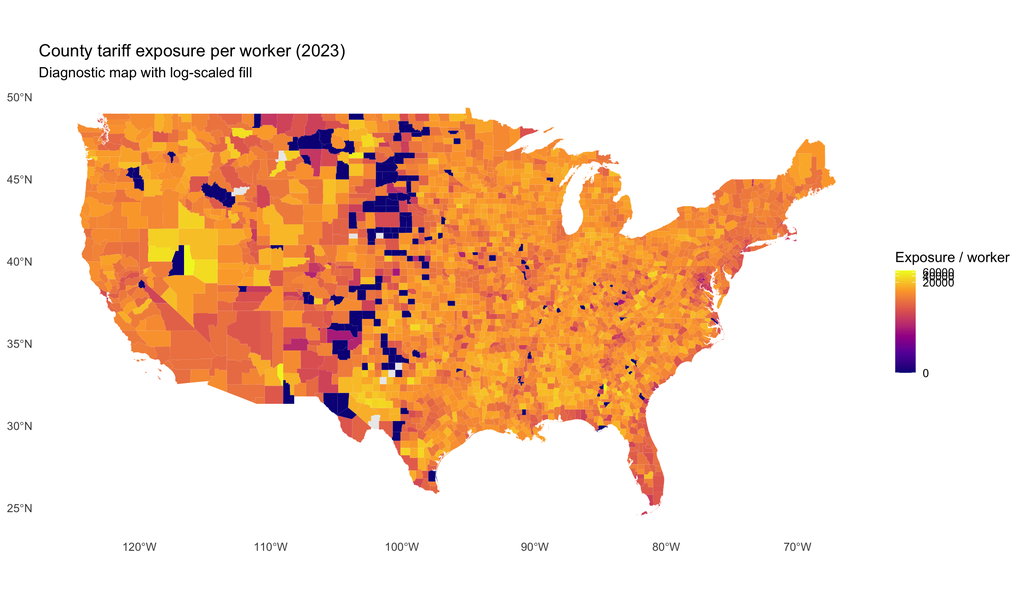

```r
options(tigris_use_cache = TRUE)

counties_sf <- tigris::counties(cb = TRUE, year = 2023, class = "sf") %>%
  sf::st_as_sf() %>%
  select(GEOID, geometry)

map_df <- counties_sf %>%
  left_join(
    latest %>% transmute(GEOID = county_fips, exposure_per_worker = county_tariff_exposure_per_worker),
    by = "GEOID"
  ) %>%
  filter(!str_sub(GEOID, 1, 2) %in% c("02", "15", "60", "66", "69", "72", "78"))

ggplot(map_df) +
  geom_sf(aes(fill = exposure_per_worker), color = NA) +
  scale_fill_viridis_c(option = "C", trans = "log1p", na.value = "grey92") +
  labs(
    title = paste0("County tariff exposure per worker (", latest_year, ")"),
    subtitle = "Diagnostic map with log-scaled fill",
    fill = "Exposure / worker"
  ) +
  theme_minimal(base_size = 12) +
  theme(panel.grid = element_blank())
```

### Checkpoint

What did the reconstruction check and NAICS audit each protect us from?

## Session 3: Regression Ladder and Optional Extensions

### Framing

The ladder structure helps us compare assumptions instead of over-committing to one specification.

Green = dependent variable Blue = main predictors Purple = FE and clustered uncertainty

$$\color{DarkGreen}{\log(1+\text{Exposure}_{ct})}
=
\beta_1 \color{MidnightBlue}{\text{GOP Share}_{c}}
+
\beta_2 \color{MidnightBlue}{\text{Swingness}_{c}}
+
\beta_3 \color{MidnightBlue}{\text{Tariffed Emp Share}_{ct}}
+
\color{DarkSlateBlue}{\text{state FE}}
+
\varepsilon_{ct}$$

```r
reg_df <- panel %>%
  mutate(
    y = log1p(county_tariff_exposure_mean),
    state_name = as.character(state_name)
  ) %>%
  filter(
    is.finite(y),
    !is.na(gop_share_20),
    !is.na(swingness_20),
    !is.na(tariffed_emp_share)
  )

reg_df %>%
  summarise(
    rows = n(),
    counties = n_distinct(county_fips),
    years = n_distinct(year)
  ) %>%
  kable()
```

| rows | counties | years |
| --- | --- | --- |
| 21717 | 3110 | 7 |

```r
m1 <- feols(y ~ gop_share_20 + swingness_20 + tariffed_emp_share,
            data = reg_df,
            vcov = "hetero")

m2 <- feols(y ~ gop_share_20 + swingness_20 + tariffed_emp_share | state_name,
            data = reg_df %>% filter(!is.na(state_name), state_name != ""),
            vcov = "hetero")

m3 <- feols(y ~ gop_share_20 + swingness_20 + tariffed_emp_share | state_name,
            data = reg_df %>% filter(!is.na(state_name), state_name != ""),
            vcov = ~state_name)

modelsummary(
  list(
    "M1 HC1" = m1,
    "M2 + State FE (HC1)" = m2,
    "M3 + State FE (Clustered)" = m3
  ),
  stars = FALSE,
  fmt = 3,
  output = "markdown"
)
```

|  | M1 HC1 | M2 + State FE (HC1) | M3 + State FE (Clustered) |
| --- | --- | --- | --- |
| (Intercept) | 15.528 |  |  |
|  | (0.253) |  |  |
| gop_share_20 | -5.655 | -5.152 | -5.152 |
|  | (0.255) | (0.267) | (1.171) |
| swingness_20 | 3.312 | 3.152 | 3.152 |
|  | (0.177) | (0.178) | (0.711) |
| tariffed_emp_share | 14.952 | 14.190 | 14.190 |
|  | (0.277) | (0.274) | (1.737) |
| Num.Obs. | 21717 | 21677 | 21677 |
| R2 | 0.292 | 0.365 | 0.365 |
| R2 Adj. | 0.292 | 0.363 | 0.363 |
| R2 Within |  | 0.236 | 0.236 |
| R2 Within Adj. |  | 0.236 | 0.236 |
| AIC | 115733.4 | 113281.4 | 113281.4 |
| BIC | 115765.3 | 113696.6 | 113696.6 |
| RMSE | 3.47 | 3.29 | 3.29 |
| Std.Errors | Heteroskedasticity-robust | Heteroskedasticity-robust | by: state_name |
| FE: state_name |  | X | X |

### Teaching takeaway

Model credibility comes from stability under stronger assumptions, not from one convenient p-value.

## Optional Campaign-Finance Extension

```r
finance_panel_path <- "data/public/derived/county_tariff_panel_with_campaign_finance.csv"

if (!file.exists(finance_panel_path)) {
  cat(
    "Campaign-finance extension data is not present yet.\n\n",
    "To build it:\n",
    "1) source('code/add_campaign_finance_county_measures.R')\n",
    "2) Set FEC_API_KEY, or provide cached ZIP files in data/public/raw/\n",
    "3) Re-knit this workbook\n"
  )
} else {
  finance_panel <- read_csv(finance_panel_path, show_col_types = FALSE) %>%
    mutate(
      county_fips = str_pad(as.character(county_fips), 5, pad = "0"),
      year = as.integer(year)
    )

  needed <- c(
    "county_fips", "year", "county_tariff_exposure_mean", "gop_share_20",
    "swingness_20", "tariffed_emp_share", "state_name", "donations_total", "spending_total"
  )
  missing_needed <- setdiff(needed, names(finance_panel))

  if (length(missing_needed) > 0) {
    cat(
      "Finance panel is present, but required columns are missing:\n",
      paste0(" - ", missing_needed, collapse = "\n"),
      "\nRebuild with code/add_campaign_finance_county_measures.R\n"
    )
  } else {
    latest_finance_year <- max(finance_panel$year, na.rm = TRUE)
    fin_latest <- finance_panel %>% filter(year == latest_finance_year)

    fin_diag <- fin_latest %>%
      summarise(
        year = latest_finance_year,
        counties = n_distinct(county_fips),
        counties_with_donations = sum(donations_total > 0, na.rm = TRUE),
        counties_with_spending = sum(spending_total > 0, na.rm = TRUE),
        median_donations = median(donations_total, na.rm = TRUE),
        median_spending = median(spending_total, na.rm = TRUE)
      )

    kable(fin_diag, digits = 2, caption = "Campaign-finance coverage (latest year)")

    reg_fin <- fin_latest %>%
      mutate(
        y = log1p(county_tariff_exposure_mean),
        ln_donations = log1p(donations_total),
        ln_spending = log1p(spending_total)
      ) %>%
      filter(
        is.finite(y),
        is.finite(ln_donations),
        is.finite(ln_spending),
        !is.na(gop_share_20),
        !is.na(swingness_20),
        !is.na(tariffed_emp_share),
        !is.na(state_name),
        state_name != ""
      )

    m_base <- feols(
      y ~ gop_share_20 + swingness_20 + tariffed_emp_share | state_name,
      data = reg_fin,
      vcov = ~state_name
    )

    m_fin <- feols(
      y ~ gop_share_20 + swingness_20 + tariffed_emp_share + ln_donations + ln_spending | state_name,
      data = reg_fin,
      vcov = ~state_name
    )

    modelsummary(
      list(
        "Baseline FE + clustered" = m_base,
        "+ Donations + spending controls" = m_fin
      ),
      stars = FALSE,
      fmt = 3,
      output = "markdown"
    )
  }
}
```

```
## Campaign-finance extension data is not present yet.
##
##  To build it:
##  1) source('code/add_campaign_finance_county_measures.R')
##  2) Set FEC_API_KEY, or provide cached ZIP files in data/public/raw/
##  3) Re-knit this workbook
```

## Final Checklist

### Checkpoint

A clean close-out explanation should answer all five:

- What the exposure formula measures
- Why geography and scaling fixes matter
- What diagnostics validated the data pipeline
- How model conclusions changed across HC1, FE, and clustered SE
- Which claims are associative versus causal

Use this master as the complete backbone. Use Session 1-3 files for delivery cadence.